# Selecting a new 3’UTR (similar to SRO9)

[output not shown]

## Compare characteristics of all 3’UTRs with 2 HWNCAUUWY motifs included

Only PIR1 / YKL164C and NGL1 / YOL042W contain the correct numbers of motifs to conduct a motif deletion assay that matches the motif addition essay previously achieved with RPS3 (and TSA1). However, both of these 3’UTRs are much longer than RPS3/TSA1 which could introduce quite a lot of unexpected effects (such as complex secondary structures). The only other option is to ignore the stability motif UGUAHMNUA which we don’t have much evidence for and concentrate on the other two decay motifs. NGL1 terminator overlaps slightly with an adjacent gene on the opposite strand. NGL1’s function isnt entirely understood but ithas a domain similar to a magnesium-dependent endonuclease motif in mRNA deadenylase. PIR1 is a O-glycosylated protein required for cell wall stability.

[output not shown]

## Compare PIR1 and NGL1 abundance

PIR1 is much more abundant, about 10 times, than NGL1 but unfortunately is very cell cycle dependent. That being said, this appears to only have a detectable effect when cells are directly synchronised.

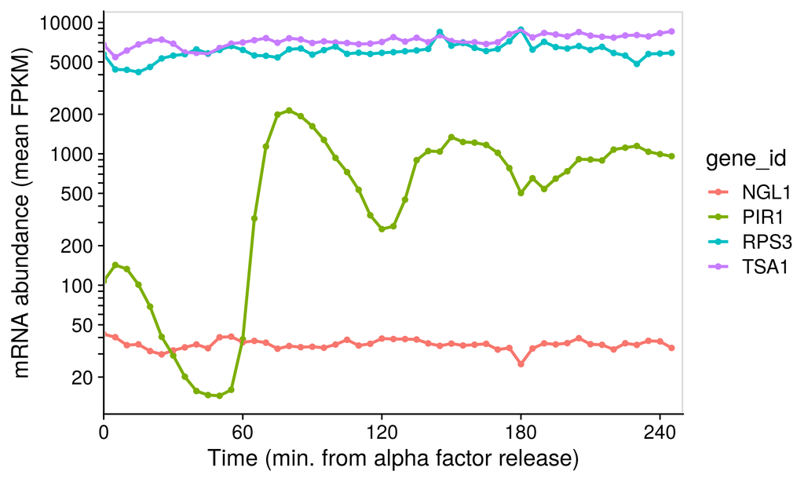

## Exploring PIR1 and NGL1 3’UTR secondary structure

### NGL1

NGL1 seems to have a more bound and linear structure with a lower kcal/mol. Only changing UGUAHMNUA appears to introduce a new and highly stable structure to NGL1. The rest of the modification make small, uncertain changes.

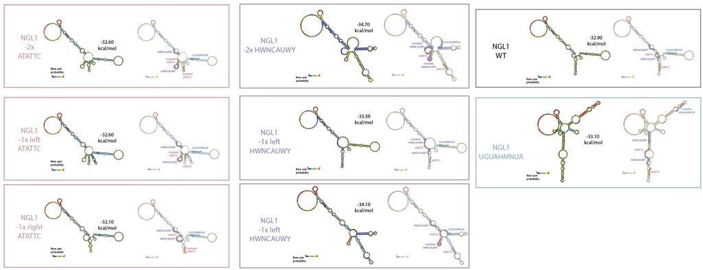

### PIR1

PIR1 first needs to be altered to remove a site matching the BsmB1 restriction enzyme which would break the modular cloning essay. Overall PIR1 appears to have a less stable structure than NGL1 (as suggested by the kcal/mol). One of the three HWNCAUUWY motifs does appear in the one well defined and tightly bound region, however. Altering this particular motif does alter the structure quite significantly. Finally, changes to the stability motif UGUAHMNUA might cause some structural changes in the centre but not quite a certain as the HWNCAUUWY.

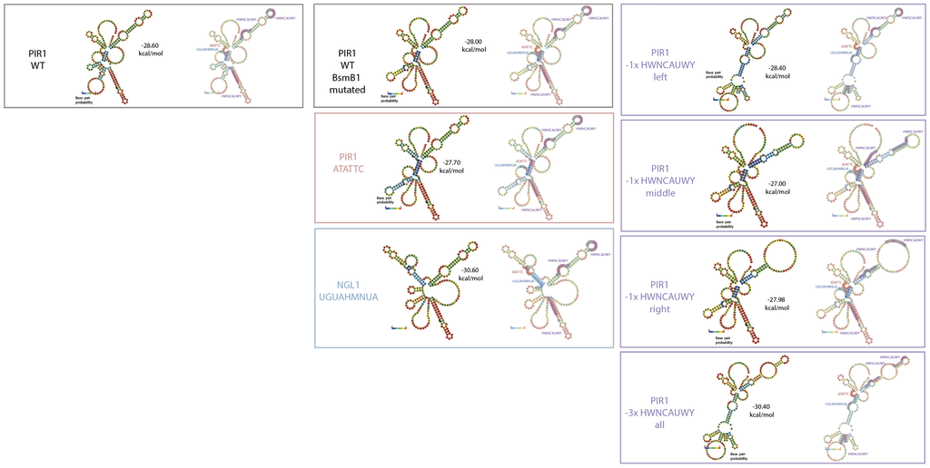

## Alternative shorter 3’UTR without UGUAHMNUA

Extending the search for a suitable 3’UTR by removing the UGUAHMNUA motif requirement. QCR8 is a shorter, only 168 nt long, 3’UTR but still highly abundant. Termintor does overlap slightly with ORF of adjacent gene on opposite strand. It doesn’t have such a dependence on the cycle cycle. It is a component of the mitochondrial inner membrane electron transport chain.

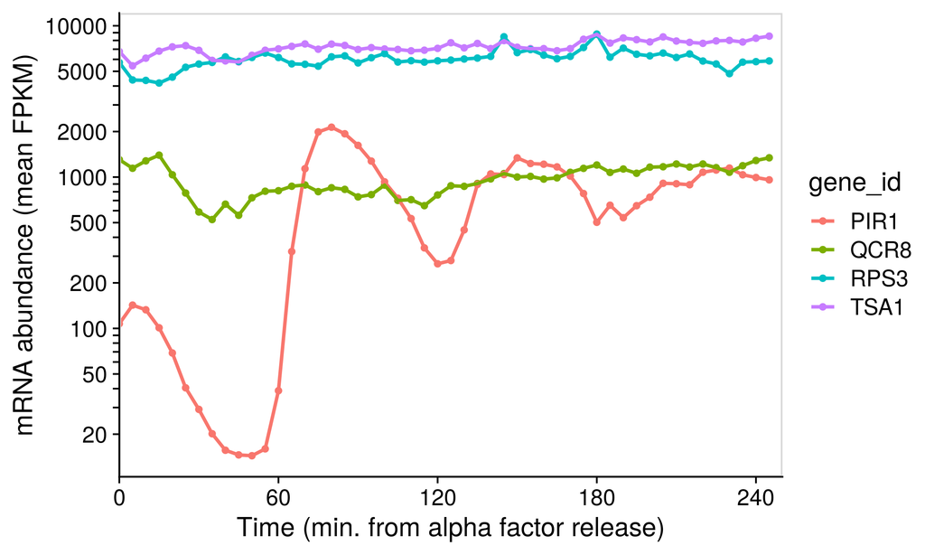